# Final_Q16

Haoyu Yue

```r
library(haven)
library(tidyverse)
library(pander)
library(dplyr)
rm(list=ls())
```

**Use ‘Q19.sav’ dataset in R. For every step, explain the output and summarize inferences based on the results obtained.**

```r
data <- read_sav("Q19.sav")
```

**(1) Many people have suggested that Americans have less than 10 hrs per day to relax. Using the dataset provided test this statement using appropriate statistical test.**

## H0: Americans have more than 10 hrs per day to relax.

### Ha: Americans have less than 10 hrs per day to relax.

```r
data_1 <- data %>%
  select("d20_hrsrelax") %>%
  na.omit()
t.test(data_1$d20_hrsrelax, alternative="less", mu=10)
```

```
##
##  One Sample t-test
##
## data:  data_1$d20_hrsrelax
## t = -86.821, df = 1232, p-value < 2.2e-16
## alternative hypothesis: true mean is less than 10
## 95 percent confidence interval:
##      -Inf 3.734231
## sample estimates:
## mean of x
##  3.613139
```

### Based on the p-value (<0.05) we can reject the null hypothesis that the true mean is more than 10 hours. So we can conclude that Americans have less than 10 hrs per day to relax.

**(2) Also, test if there is a difference in number of hours per day to relax among men and women.**

H0: There is no difference in number of hours per day to relax among men and women.

**(3) Assume you are interested in understanding the relationship between hours per day they have to relax (dependent variable), age, gender (male/female), years of education (highest year of school completed), social class, and marital status (Married vs Not Married*). Run appropriate statistical tests and prepare a summary report that includes:**

- Research question
- Description of the variables
- Appropriate statistical tests
- Appropriate diagnostic tests
- Summary of your findings

**Research question**

What is the relationship among all these variables? How these independent variables impact the dependent variable?

**Description of the variables**

```r
unique(data$d10_marital)
```

```
## <labelled<double>[6]>: MARITAL STATUS
## [1]  3  1  5  4  2 NA
##
## Labels:
##  value         label
##      1       MARRIED
##      2       WIDOWED
##      3      DIVORCED
##      4     SEPARATED
##      5 NEVER MARRIED
##      9            NA
```

```r
data_3 <- data %>%
  na.omit() %>%
  mutate(marriage = case_when(d10_marital == 1 ~ "1", d10_marital == 4 ~ "1", TRUE ~ "0" )) %>%
  select(-d10_marital)
names(data_3)
```

```
## [1] "d20_hrsrelax" "d5_sex"       "d1_age"       "d4_educ"      "d11_class"
## [6] "marriage"
```

```r
pander(psych::describe(data_3))
```

Table continues below

|  | vars | n | mean | sd | median | trimmed | mad |
| --- | --- | --- | --- | --- | --- | --- | --- |
| **d20_hrsrelax** | 1 | 1223 | 3.618 | 2.588 | 3 | 3.346 | 1.483 |
| **d5_sex** | 2 | 1223 | 1.511 | 0.5001 | 2 | 1.514 | 0 |
| **d1_age** | 3 | 1223 | 44.11 | 13.43 | 44 | 43.89 | 16.31 |
| **d4_educ** | 4 | 1223 | 14.05 | 2.927 | 14 | 14.06 | 2.965 |
| **d11_class** | 5 | 1223 | 2.404 | 0.6283 | 2 | 2.409 | 0 |
| **marriage*** | 6 | 1223 | 1.512 | 0.5001 | 2 | 1.515 | 0 |

|  | min | max | range | skew | kurtosis | se |
| --- | --- | --- | --- | --- | --- | --- |
| **d20_hrsrelax** | 0 | 24 | 24 | 1.904 | 7.496 | 0.07399 |
| **d5_sex** | 1 | 2 | 1 | -0.04411 | -2 | 0.0143 |
| **d1_age** | 18 | 79 | 61 | 0.1213 | -0.8892 | 0.3839 |
| **d4_educ** | 0 | 20 | 20 | -0.4199 | 1.794 | 0.08368 |
| **d11_class** | 1 | 4 | 3 | 0.08822 | -0.2204 | 0.01797 |
| **marriage*** | 1 | 2 | 1 | -0.04738 | -1.999 | 0.0143 |

- Variable “d20_hrsrelax*” means the hours of relaxation. It’s a interval-ratio variable. Min = 0, Max = 24, Means = 3.6, SD = 2.588, Range = 24.
- Variable “d5_sex” means response’s gender. It’s a nominal variable. Value 1 is male and 2 is female.
- Variable “d1_age” means response’s age. It’s a interval-ratio variable. Min = 18, Max = 79, Means = 44.1, SD = 13.43, Range = 61.
- Variable “d4_educ” means response’s years of education. It’s a interval-ratio variable. Min = 0, Max = 20, Means = 14.05, SD = 2.93, Range = 20.
- Variable “d11_class” means response’s subjective class identification. It’s a ordinal variable. The range is 3 and the SD is 0.63. Max = 4, Min = 1.
- Variable “marriage” means response’s marriage status. It’s a nominal variable. 0 means not married and 1 means married.

**Statistical tests**

```r
pander(Hmisc::rcorr(as.matrix(data_3), type = "pearson"),split.tables=Inf)
```

- **r**:

  Table continues below

  |  | d20_hrsrelax | d5_sex | d1_age | d4_educ | d11_class |
  | --- | --- | --- | --- | --- | --- |
  | **d20_hrsrelax** | 1 | -0.09128 | 0.09238 | -0.05673 | -0.02233 |
  | **d5_sex** | -0.09128 | 1 | -0.008959 | 0.02729 | -0.09233 |
  | **d1_age** | 0.09238 | -0.008959 | 1 | 0.03372 | 0.1528 |
  | **d4_educ** | -0.05673 | 0.02729 | 0.03372 | 1 | 0.3745 |
  | **d11_class** | -0.02233 | -0.09233 | 0.1528 | 0.3745 | 1 |
  | **marriage** | -0.0765 | -0.05861 | 0.1762 | 0.1011 | 0.1462 |

  |  | marriage |
  | --- | --- |
  | **d20_hrsrelax** | -0.0765 |
  | **d5_sex** | -0.05861 |
  | **d1_age** | 0.1762 |
  | **d4_educ** | 0.1011 |
  | **d11_class** | 0.1462 |
  | **marriage** | 1 |

- **n**:

  |  | d20_hrsrelax | d5_sex | d1_age | d4_educ | d11_class | marriage |
  | --- | --- | --- | --- | --- | --- | --- |
  | **d20_hrsrelax** | 1223 | 1223 | 1223 | 1223 | 1223 | 1223 |
  | **d5_sex** | 1223 | 1223 | 1223 | 1223 | 1223 | 1223 |
  | **d1_age** | 1223 | 1223 | 1223 | 1223 | 1223 | 1223 |
  | **d4_educ** | 1223 | 1223 | 1223 | 1223 | 1223 | 1223 |
  | **d11_class** | 1223 | 1223 | 1223 | 1223 | 1223 | 1223 |
  | **marriage** | 1223 | 1223 | 1223 | 1223 | 1223 | 1223 |

- **P**:

  Table continues below

  |  | d20_hrsrelax | d5_sex | d1_age | d4_educ | d11_class |
  | --- | --- | --- | --- | --- | --- |
  | **d20_hrsrelax** | NA | 0.001395 | 0.001219 | 0.04733 | 0.4353 |
  | **d5_sex** | 0.001395 | NA | 0.7543 | 0.3403 | 0.001227 |
  | **d1_age** | 0.001219 | 0.7543 | NA | 0.2387 | 7.901e-08 |
  | **d4_educ** | 0.04733 | 0.3403 | 0.2387 | NA | 0 |
  | **d11_class** | 0.4353 | 0.001227 | 7.901e-08 | 0 | NA |
  | **marriage** | 0.007442 | 0.04043 | 5.523e-10 | 0.0003999 | 2.808e-07 |

  |  | marriage |
  | --- | --- |
  | **d20_hrsrelax** | 0.007442 |
  | **d5_sex** | 0.04043 |
  | **d1_age** | 5.523e-10 |
  | **d4_educ** | 0.0003999 |
  | **d11_class** | 2.808e-07 |
  | **marriage** | NA |

- **type**: pearson

Hours per day they have to relax = a + b1(sex) + b2(age) + b3(educ) + b4(class) + b5(marriage)

```r
model_1 <- lm(d20_hrsrelax ~ as.factor(d5_sex) + d1_age + d4_educ + d11_class + as.factor(marriage), data=data_3)
pander(summary(model_1))
```

|  | Estimate | Std. Error | t value | Pr(>\|t\|) |
| --- | --- | --- | --- | --- |
| **(Intercept)** | 3.868 | 0.4511 | 8.575 | 2.956e-17 |
| **as.factor(d5_sex)2** | -0.4993 | 0.1473 | -3.39 | 0.0007225 |
| **d1_age** | 0.0217 | 0.005582 | 3.887 | 0.0001069 |
| **d4_educ** | -0.03635 | 0.02705 | -1.344 | 0.1792 |
| **d11_class** | -0.07885 | 0.1282 | -0.6151 | 0.5386 |
| **as.factor(marriage)1** | -0.4917 | 0.15 | -3.278 | 0.001076 |

Fitting linear model: d20_hrsrelax ~ as.factor(d5_sex) + d1_age + d4_educ + d11_class + as.factor(marriage)

| Observations | Residual Std. Error | *R*<sup>2</sup> | Adjusted *R*<sup>2</sup> |
| --- | --- | --- | --- |
| 1223 | 2.555 | 0.02924 | 0.02525 |

```r
pander(lm.beta::lm.beta(model_1))
```

Fitting linear model: d20_hrsrelax ~ as.factor(d5_sex) + d1_age + d4_educ + d11_class + as.factor(marriage) (continued below)

|  | Estimate | Standardized | Std. Error | t value |
| --- | --- | --- | --- | --- |
| **(Intercept)** | 3.868 | NA | 0.4511 | 8.575 |
| **as.factor(d5_sex)2** | -0.4993 | -0.09649 | 0.1473 | -3.39 |
| **d1_age** | 0.0217 | 0.1126 | 0.005582 | 3.887 |
| **d4_educ** | -0.03635 | -0.04111 | 0.02705 | -1.344 |
| **d11_class** | -0.07885 | -0.01915 | 0.1282 | -0.6151 |
| **as.factor(marriage)1** | -0.4917 | -0.09503 | 0.15 | -3.278 |

|  | Pr(>\|t\|) |
| --- | --- |
| **(Intercept)** | 2.956e-17 |
| **as.factor(d5_sex)2** | 0.0007225 |
| **d1_age** | 0.0001069 |
| **d4_educ** | 0.1792 |
| **d11_class** | 0.5386 |
| **as.factor(marriage)1** | 0.001076 |

**Diagnostic tests**

- Check for Influential Data

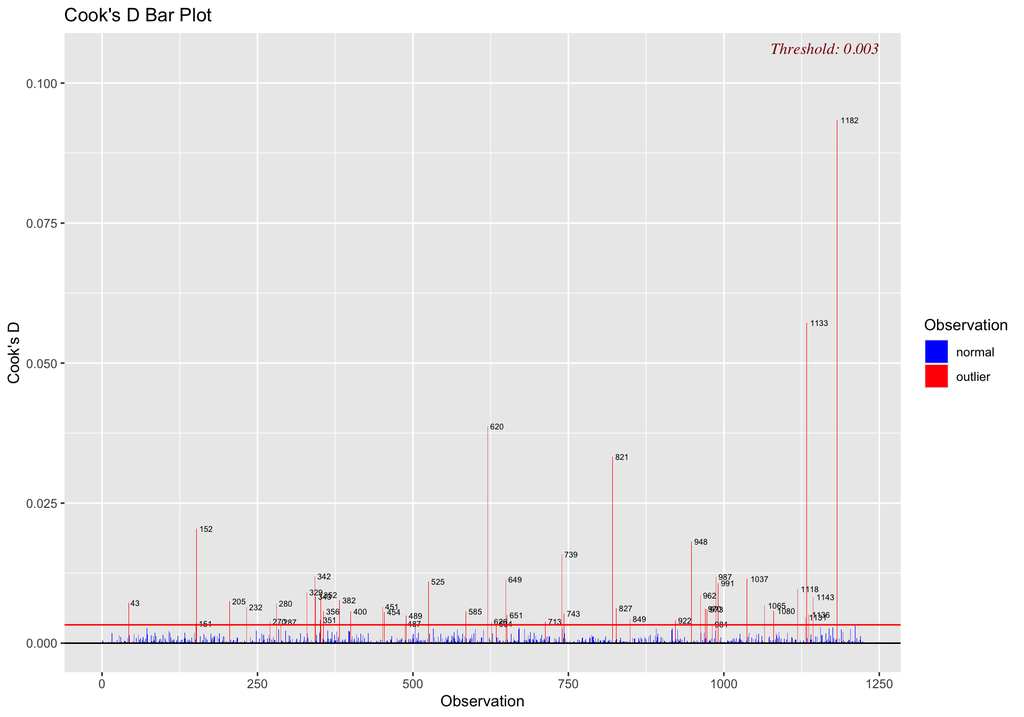

```r
olsrr::ols_plot_cooksd_bar(model_1)
```

The values above the threshold line will affect the liner regression model.

- Test for normality of residuals

```r
olsrr::ols_test_normality(model_1)
```

```
## -----------------------------------------------
##        Test             Statistic       pvalue
## -----------------------------------------------
## Shapiro-Wilk              0.8837         0.0000
## Kolmogorov-Smirnov        0.0861         0.0000
## Cramer-von Mises         99.9681         0.0000
## Anderson-Darling         21.5855         0.0000
## -----------------------------------------------
```

Ho: The distribution is normal

All p-values are equal to 0.0000. Hence we can reject the null hypothesis that the residuals are normally distributes. So the distribution is not normal.

- Test for Homoscedasticity

```r
olsrr::ols_test_breusch_pagan(model_1)
```

```
##
##  Breusch Pagan Test for Heteroskedasticity
##  -----------------------------------------
##  Ho: the variance is constant
##  Ha: the variance is not constant
##
##                   Data
##  ----------------------------------------
##  Response : d20_hrsrelax
##  Variables: fitted values of d20_hrsrelax
##
##          Test Summary
##  -------------------------------
##  DF            =    1
##  Chi2          =    41.15709
##  Prob > Chi2   =    1.404725e-10
```

As p-value is close to 0.0000, the variance is not constant. Hence the assumption of Homoskedesticity is false.

- Tests for Multicollinearity

```r
olsrr::ols_vif_tol(model_1)
```

```
##              Variables Tolerance      VIF
## 1   as.factor(d5_sex)2 0.9843970 1.015850
## 2               d1_age 0.9511529 1.051356
## 3              d4_educ 0.8523624 1.173210
## 4            d11_class 0.8234557 1.214394
## 5 as.factor(marriage)1 0.9489917 1.053750
```

VIF for all variables < 6. Hence, not much correlation among independent variables.

- Test for Linearity

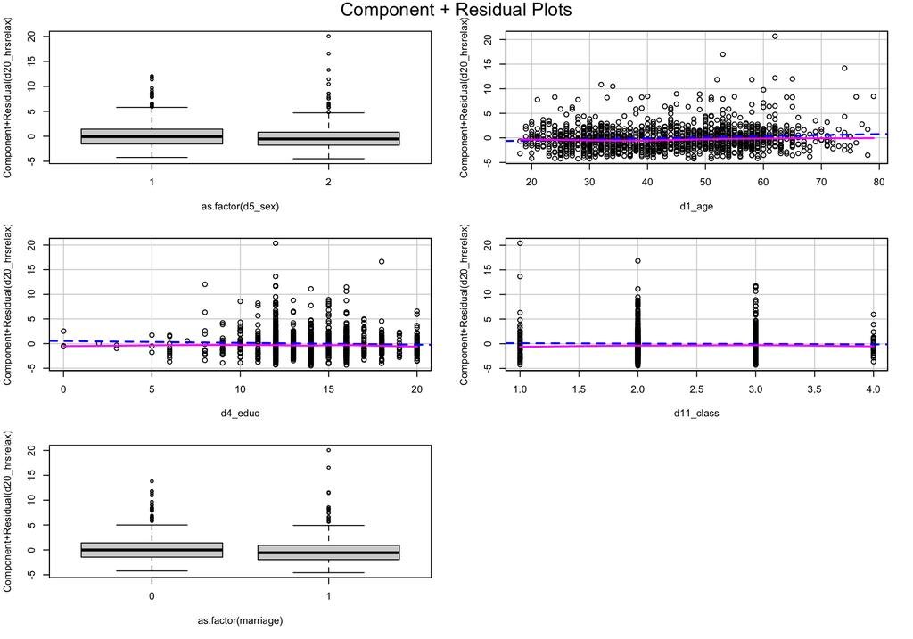

```r
car::crPlots(model_1)
```

- Model Specification Error

Ho: Model has no Omitted variables

Ideally if p>0.05 then no specification error

```r
lmtest::resettest(model_1, power = 2:3, type = "regressor")
```

```
##
##  RESET test
##
## data:  model_1
## RESET = 1.1637, df1 = 6, df2 = 1211, p-value = 0.3233
```

p-value is more than 0.05 and we can not reject the null hyphothsis. Hence, the model does not have omitted variables.

- Issues of Independence

```r
lmtest::dwtest(model_1)
```

```
##
##  Durbin-Watson test
##
## data:  model_1
## DW = 2.009, p-value = 0.5597
## alternative hypothesis: true autocorrelation is greater than 0
```

p-value > 0.05. Hence, we cannot reject the null hypothesis. This means that there is no evidence of autocorrelation.

**Summarize findings**

```r
unique(data_3$d5_sex)
```

```
## <labelled<double>[2]>: RESPONDENTS SEX
## [1] 1 2
##
## Labels:
##  value  label
##      1   MALE
##      2 FEMALE
```

Predicting hours per day they have to relax using percent of age, gender, years of education, social class, marital status leads to a reduction in errors by 2%.

Controlling for other variables in the model:

As age increases by 1, the hours per day they have to relax will increase by 0.02.

As years of education increases by 1, the hours per day they have to relax will decrease by 0.036.

As social class increases by 1, the hours per day they have to relax will decrease by 0.078.

Hours per day they have to relax for females is 0.499 lower than that of males.

Hours per day they have to relax for married persons is 0.492 lower than that of unmarried persons.

Coefficients of gender, age, marriage status are statistically significant with p-value < 0.05, Hence we can say with high confidence that there is a relationship between hours per day they have to relax and gender, age, marriage status. And all coefficients are not equal to 0.

Coefficient of social class and years of education are not statistically significant with p-value > 0.05. Hence we cannot say with high confidence that there is a relationship between hours per day they have to relax and social class, years of education.

As we can see that there are many influential data and many assumptions are false. Meanwhile, from the regression, we can know that the R square is 0.02, extremely small, so maybe we need to do more next for improving the model.